# IRM spatial data preparation

# Introduction

The IRM crop suitability model requires spatial data for the various biophysical criteria or requirements.

The global or continental data are often too large to store in the IRM spatial data directory.

Therefore we will create a mask of Nigeria that we will use to clip the other data.

We will also merge soil raster data that have separate files for different soil horizons. These will be weighted and used in the IRM, but need to be saved previously as separate bands in a raster GeoTiff file.

# Mask and Resolution

The mask will be the boundary of Nigeria using the states dataset that we use throughout the Atlas.

The spatial resolution will be 5km, but at this stage we will only use the boundary to clip the data using its native resolution. The clip will include all pixels touching the boundary.

```r
wkt_geo <-  paste0( "
  GEOGCRS[\"WGS 84 (with axis order normalized for visualization)\",
          ENSEMBLE[\"World Geodetic System 1984 ensemble\",
                   MEMBER[\"World Geodetic System 1984 (Transit)\",
                          ID[\"EPSG\",1166]],
                   MEMBER[\"World Geodetic System 1984 (G730)\",
                          ID[\"EPSG\",1152]],
                   MEMBER[\"World Geodetic System 1984 (G873)\",
                          ID[\"EPSG\",1153]],
                   MEMBER[\"World Geodetic System 1984 (G1150)\",
                          ID[\"EPSG\",1154]],
                   MEMBER[\"World Geodetic System 1984 (G1674)\",
                          ID[\"EPSG\",1155]],
                   MEMBER[\"World Geodetic System 1984 (G1762)\",
                          ID[\"EPSG\",1156]],
                   MEMBER[\"World Geodetic System 1984 (G2139)\",
                          ID[\"EPSG\",1309]],
                   ELLIPSOID[\"WGS 84\",6378137,298.257223563,
                             LENGTHUNIT[\"metre\",1],
                             ID[\"EPSG\",7030]],
                   ENSEMBLEACCURACY[2.0],
                   ID[\"EPSG\",6326]],
          PRIMEM[\"Greenwich\",0,
                 ANGLEUNIT[\"degree\",0.0174532925199433],
                 ID[\"EPSG\",8901]],
          CS[ellipsoidal,2],
          AXIS[\"geodetic longitude (Lon)\",east,
               ORDER[1],
               ANGLEUNIT[\"degree\",0.0174532925199433,
                         ID[\"EPSG\",9122]]],
          AXIS[\"geodetic latitude (Lat)\",north,
               ORDER[2],
               ANGLEUNIT[\"degree\",0.0174532925199433,
                         ID[\"EPSG\",9122]]],
          USAGE[
            SCOPE[\"Horizontal component of 3D system.\"],
            AREA[\"World.\"],
            BBOX[-90,-180,90,180]],
          REMARK[\"Axis order reversed compared to EPSG:4326\"]]")
```

# Load the Nigeria boundary

```r
vect_state_geo <- vect("D:/DatosProyecto/SpatialData/Africa/Pais/Nigeria/NGA Admin 2019-2025 OSGOF-Ehealth-UNCS/nga_admin1_topo.topojson")

vect_ng_geo <- vect_state_geo |> aggregate(by = "adm0_pcode")

crs(vect_ng_geo) <- "epsg:4326"

vect_ng_geo$adm0_pcode <- as.factor(vect_ng_geo$adm0_pcode)

ext(vect_ng_geo)
```

SpatExtent : 2.6685336, 14.6788162, 4.2730074, 13.8944191 (xmin, xmax, ymin, ymax)

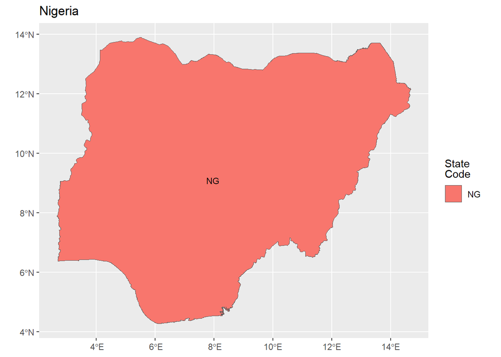

```r
ggplot(vect_ng_geo)+
  geom_spatvector(aes(fill = adm0_pcode)) +
  geom_spatvector_text(aes(label = adm0_pcode), size = 3) +
  labs(
    title = "Nigeria",
    fill = "State<br>Code") +
  theme(
    plot.title = element_markdown(),
    legend.title = element_markdown(),
    axis.title = element_blank()
  )
```

## Land Use

The purpose of including a land use criteria is to assess whether the existing land use is suitable for the crop. Normally in a crop suitability model a land cover like shrubland, or forest would not be suitable for crops due to the environmental impacts. But in our case we are concerned with whether it is feasible to convert the land to cropland. Therefore we include all land use types that are not urban, water, flooded or bare.

https://collections.sentinel-hub.com/worldcover/readme.html

| Value | Label | Agricultural Land value |
| --- | --- | --- |
| 10 | Tree cover | 1 |
| 20 | Shrubland | 1 |
| 30 | Grassland | 1 |
| 40 | Cropland | 1 |
| 50 | Built-up | 0 |
| 60 | Bare / sparse vegetation | 0 |
| 70 | Snow and ice | 0 |
| 80 | Permanent water bodies | 0 |
| 90 | Herbaceous wetland | 0 |
| 95 | Mangroves | 0 |
| 100 | Moss and lichen | 0 |
| 0 | No data | 0 |

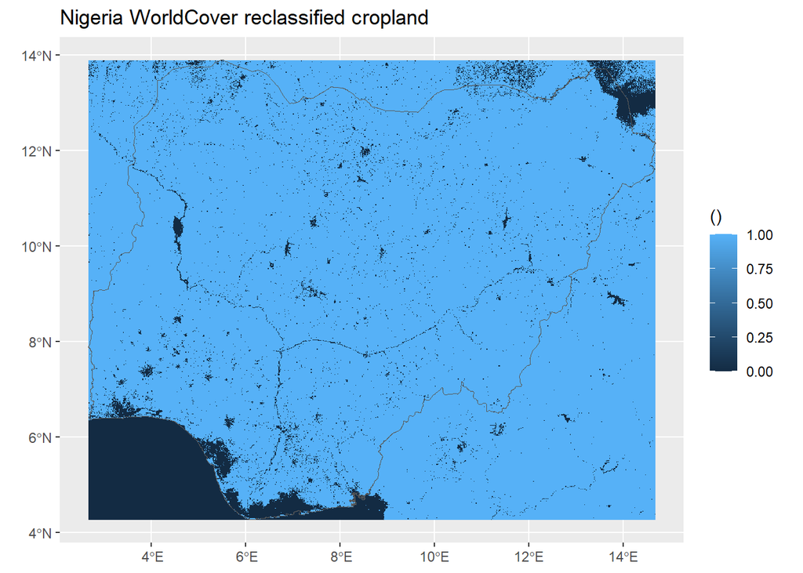

```r
# RUN ONCE TO GENERATE THE DATA - THEREAFTER THE SAVED DATA ARE LOADED FOR DISPLAY

# rast_landuse <- rast("E:/SpatialDataExternal/WorldCover_v200/terrascope_download_20241127_121517/WORLDCOVER/ESA_WORLDCOVER_10M_2021_V200/Worldcover_v_200_Nigeria-mosaic.tif")
#
# rast_landuse
#
# rast_landuse_ng <- crop(rast_landuse, vect_ng_geo)
#
# rast_landuse_ng
#
# rm(rast_landuse)
#
# gc()
#
# plot(rast_landuse_ng)
# plot(vect_ng_geo, fill = NA, add = T)
#
#
# # classify land cover
#
# df_landcover_lookup <- tribble(
#   ~wc_value, ~irm_value,
# 10, 1,
# 20, 1,
# 30, 1,
# 40, 1,
# 50, 0,
# 60, 0,
# 70, 0,
# 80, 0,
# 90, 0,
# 95, 0,
# 100, 0,
# 0, 0)
#
# m_landcover_lookup <- as.matrix(df_landcover_lookup)
#
# rast_landuse_rcl_ng <- classify(rast_landuse_ng, m_landcover_lookup)
# rast_landuse_rcl_ng


# RUN ONCE TO SAVE THE DATA - THEREAFTER THE SAVED DATA ARE LOADED FOR DISPLAY

# writeRaster(rast_landuse_rcl_ng, "E:/repos/IRM_shiny/data/spatial_data/worldcover200_rcl_30m_nigeria.tif", overwrite=TRUE)

rast_landuse_rcl_ng <- rast("E:/repos/IRM_shiny/data/spatial_data/worldcover200_rcl_30m_nigeria.tif")

ggplot()+
  geom_spatraster(data = rast_landuse_rcl_ng) +
  geom_spatvector(data = vect_ng_geo, fill = NA) +
  labs(
    title = "Nigeria WorldCover reclassified cropland",
    fill = "()") +
  theme(
    plot.title = element_markdown(),
    legend.title = element_markdown(),
    axis.title = element_blank()
  )
```

## Climate

### Precipitation

CHIRPS cumulative rainfall amounts - dekadal, monthly averages (https://data.chc.ucsb.edu/products/CHIRPS-2.0/)

Using the 30 year average for 1991-2020.

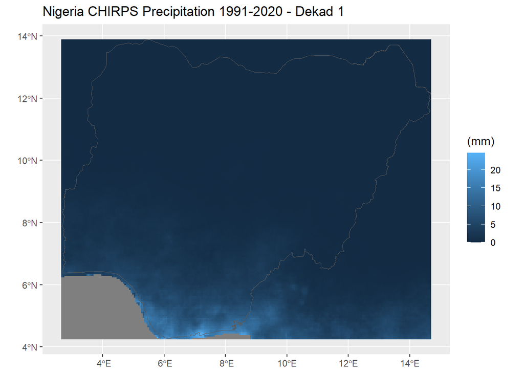

```r
# RUN ONCE TO GENERATE THE DATA - THEREAFTER THE SAVED DATA ARE LOADED FOR DISPLAY

# rast_chirps_d <- rast("E:/SpatialDataExternal/CHIRPSv3/raw_data/chirps_9120_avg.tif")
#
# rast_chirps_d
#
# rast_chirps_d_ng <- crop(rast_chirps_d, vect_ng_geo)
#
# rast_chirps_d_ng
#
# rm(rast_chirps_d)
#
# gc()

# RUN ONCE TO SAVE THE DATA - THEREAFTER THE SAVED DATA ARE LOADED FOR DISPLAY

# writeRaster(rast_chirps_d_ng, "E:/repos/IRM_shiny/data/spatial_data/chirps_9120_nigeria.tif", overwrite=TRUE)


rast_chirps_d_ng <- rast("E:/repos/IRM_shiny/data/spatial_data/chirps_9120_nigeria.tif")


ggplot()+
  geom_spatraster(data = rast_chirps_d_ng$r9120_dekad011_avg) +
  geom_spatvector(data = vect_ng_geo, fill = NA) +
  labs(
    title = "Nigeria CHIRPS Precipitation 1991-2020 - Dekad 1",
    fill = "(mm)") +
  theme(
    plot.title = element_markdown(),
    legend.title = element_markdown(),
    axis.title = element_blank()
  )
```

### Temperature

CHELSA

Using the 30 year average for 1981-2010.

#### Monthly mean daily average temperature

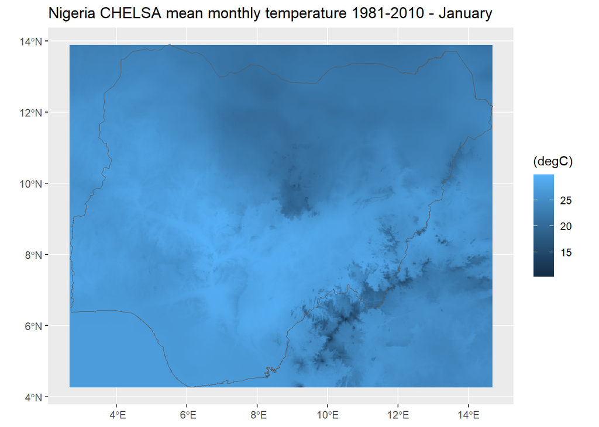

```r
# RUN ONCE TO GENERATE THE DATA - THEREAFTER THE SAVED DATA ARE LOADED FOR DISPLAY

# rast_chelsa_tas_m <- rast("E:/SpatialDataExternal/CHELSA/climatologies/tas/CHELSA_tas_year_1981-2010_V.2.1.tif")
#
# rast_chelsa_tas_m
#
# rast_chelsa_tas_m_ng <- crop(rast_chelsa_tas_m, vect_ng_geo)
#
# rast_chelsa_tas_m_ng
#
# rm(rast_chelsa_tas_m)
#
# gc()


# RUN ONCE TO SAVE THE DATA - THEREAFTER THE SAVED DATA ARE LOADED FOR DISPLAY

# writeRaster(rast_chelsa_tas_m_ng, "E:/repos/IRM_shiny/data/spatial_data/chelsa_tas_8110_nigeria.tif", overwrite=TRUE)

rast_chelsa_tas_m_ng <- rast("E:/repos/IRM_shiny/data/spatial_data/chelsa_tas_8110_nigeria.tif")


ggplot()+
  geom_spatraster(data = rast_chelsa_tas_m_ng$`CHELSA_tas_01_1981-2010_V.2.1`) +
  geom_spatvector(data = vect_ng_geo, fill = NA) +
  labs(
    title = "Nigeria CHELSA mean monthly temperature 1981-2010 - January",
    fill = "(degC)") +
  theme(
    plot.title = element_markdown(),
    legend.title = element_markdown(),
    axis.title = element_blank()
  )
```

#### Monthly mean daily minimum temperature

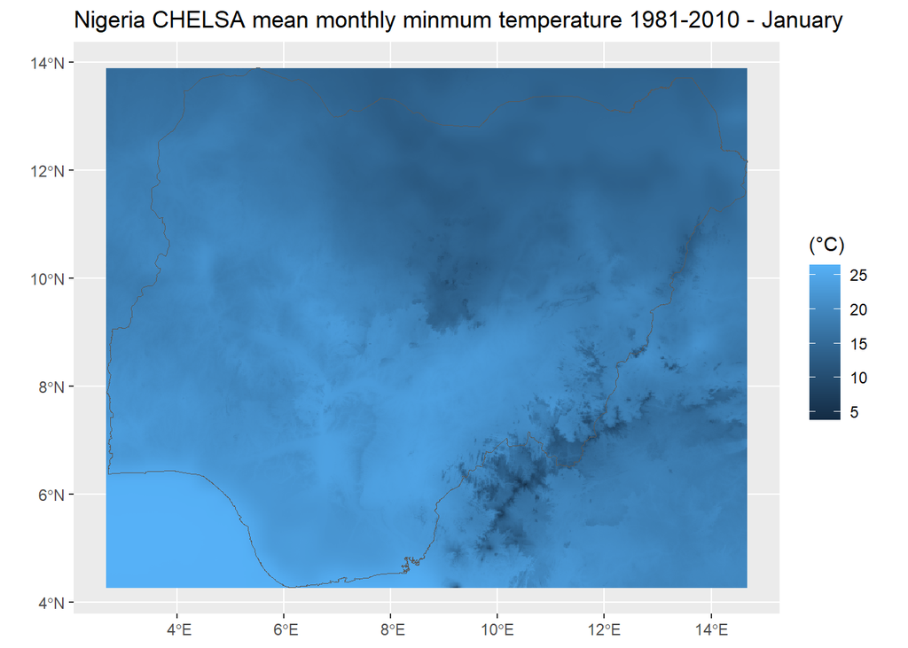

```r
# RUN ONCE TO GENERATE THE DATA - THEREAFTER THE SAVED DATA ARE LOADED FOR DISPLAY

# rast_chelsa_tasmin_m <- rast("E:/SpatialDataExternal/CHELSA/climatologies/tasmin/CHELSA_tasmin_year_1981-2010_V.2.1.tif")
#
# rast_chelsa_tasmin_m
#
# rast_chelsa_tasmin_m_ng <- crop(rast_chelsa_tasmin_m, vect_ng_geo)
#
# rast_chelsa_tasmin_m_ng
#
# rm(rast_chelsa_tasmin_m)
#
# gc()

# RUN ONCE TO SAVE THE DATA - THEREAFTER THE SAVED DATA ARE LOADED FOR DISPLAY

# writeRaster(rast_chelsa_tasmin_m_ng, "E:/repos/IRM_shiny/data/spatial_data/chelsa_tasmin_8110_nigeria.tif", overwrite=TRUE)

rast_chelsa_tasmin_m_ng <- rast("E:/repos/IRM_shiny/data/spatial_data/chelsa_tasmin_8110_nigeria.tif")


ggplot()+
  geom_spatraster(data = rast_chelsa_tasmin_m_ng$`CHELSA_tasmin_01_1981-2010_V.2.1`) +
  geom_spatvector(data = vect_ng_geo, fill = NA) +
  labs(
    title = "Nigeria CHELSA mean monthly minmum temperature 1981-2010 - January",
    fill = "(°C)") +
  theme(
    plot.title = element_markdown(),
    legend.title = element_markdown(),
    axis.title = element_blank()
  )
```

#### Monthly mean daily maximum temperature

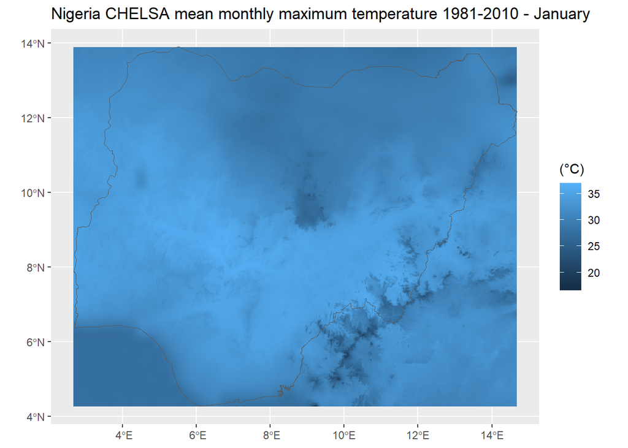

```r
# RUN ONCE TO GENERATE THE DATA - THEREAFTER THE SAVED DATA ARE LOADED FOR DISPLAY

# rast_chelsa_tasmax_m <- rast("E:/SpatialDataExternal/CHELSA/climatologies/tasmax/CHELSA_tasmax_year_1981-2010_V.2.1.tif")
#
# rast_chelsa_tasmax_m
#
# rast_chelsa_tasmax_m_ng <- crop(rast_chelsa_tasmax_m, vect_ng_geo)
#
# rast_chelsa_tasmax_m_ng
#
# rm(rast_chelsa_tasmax_m)
#
# gc()


# RUN ONCE TO SAVE THE DATA - THEREAFTER THE SAVED DATA ARE LOADED FOR DISPLAY

# writeRaster(rast_chelsa_tasmax_m_ng, "E:/repos/IRM_shiny/data/spatial_data/chelsa_tasmax_8110_nigeria.tif", overwrite=TRUE)

rast_chelsa_tasmax_m_ng <- rast("E:/repos/IRM_shiny/data/spatial_data/chelsa_tasmax_8110_nigeria.tif")


ggplot()+
  geom_spatraster(data = rast_chelsa_tasmax_m_ng$`CHELSA_tasmax_01_1981-2010_V.2.1`) +
  geom_spatvector(data = vect_ng_geo, fill = NA) +
  labs(
    title = "Nigeria CHELSA mean monthly maximum temperature 1981-2010 - January",
    fill = "(°C)") +
  theme(
    plot.title = element_markdown(),
    legend.title = element_markdown(),
    axis.title = element_blank()
  )
```

#### Monthly minimum daily minimum temperature

Raw CHELSA V2.1 temperatures are stored in Kelvin as scaled integers, so the stored values are never negative. In the documentation, the temperature variables are given as K × 10 (for example, 2731 means 273.1 K). To get °C you apply a scale factor of 0.1 and an offset of -273.15.

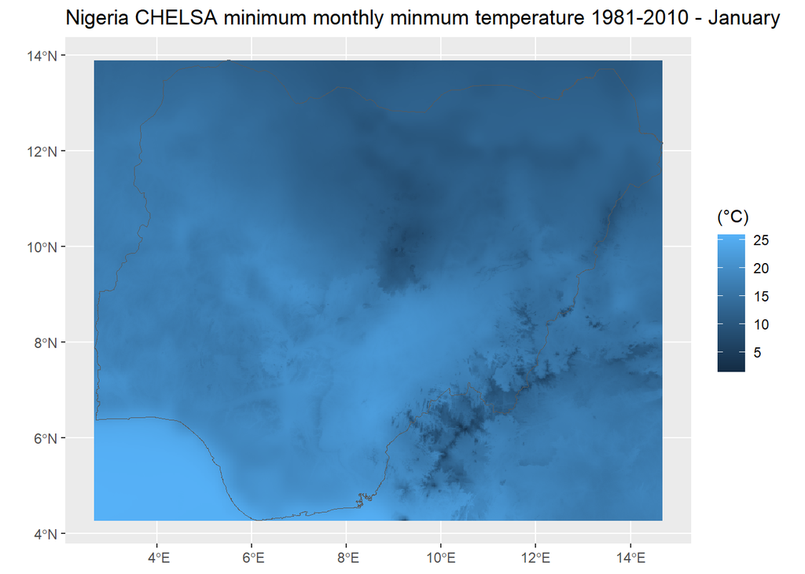

```r
# RUN ONCE TO GENERATE THE DATA - THEREAFTER THE SAVED DATA ARE LOADED FOR DISPLAY

# rast_chelsa_tasminmin_y <- rast("E:/SpatialDataExternal/CHELSA/climatologies/tasminmin/CHELSA_tasmin_min_year_1981_2010.tif")
#
# rast_chelsa_tasminmin_y
#
# rast_chelsa_tasminmin_y_ng <- crop(rast_chelsa_tasminmin_y, vect_ng_geo)
# rast_chelsa_tasminmin_y_ng <- ((rast_chelsa_tasminmin_y_ng / 10) -273.15)
#
# rast_chelsa_tasminmin_y_ng
#
# rm(rast_chelsa_tasminmin_y)
#
# gc()
#
# names(rast_chelsa_tasminmin_y_ng) <- c("Jan", "02", "03", "04", "05", "06", "07", "08","09", "10", "11", "12")
#
# rast_chelsa_tasminmin_y_ng

# RUN ONCE TO SAVE THE DATA - THEREAFTER THE SAVED DATA ARE LOADED FOR DISPLAY

# writeRaster(rast_chelsa_tasminmin_y_ng, "E:/repos/IRM_shiny/data/spatial_data/chelsa_tasminmin_y_8110_nigeria.tif", overwrite=TRUE)

rast_chelsa_tasminmin_y_ng <- rast("E:/repos/IRM_shiny/data/spatial_data/chelsa_tasminmin_y_8110_nigeria.tif")


ggplot() +
  geom_spatraster(data = rast_chelsa_tasminmin_y_ng$Jan) +
  geom_spatvector(data = vect_ng_geo, fill = NA) +
  labs(
    title = "Nigeria CHELSA minimum monthly minmum temperature 1981-2010 - January",
    fill = "(°C)") +
  theme(
    plot.title = element_markdown(),
    legend.title = element_markdown(),
    axis.title = element_blank()
  )
```

## Landscape

### Slope

We use existing sources of high resolution. Use existing SRTM 90m data

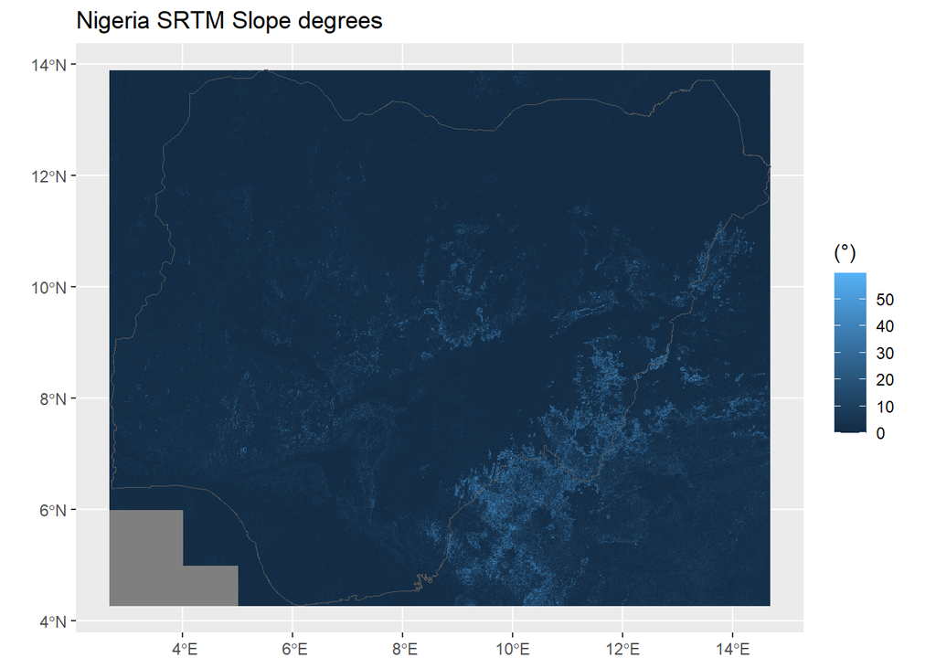

```r
# RUN ONCE TO GENERATE THE DATA - THEREAFTER THE SAVED DATA ARE LOADED FOR DISPLAY

# rast_srtm90 <- rast("E:/repos_external/RDC_Aptitud/spatial_data/input/srtm_slope.tif")
#
# rast_srtm90
#
# rast_srtm90_ng <- crop(rast_srtm90, vect_ng_geo)
#
# rast_srtm90_ng
#
# rm(rast_srtm90)
#
# gc()

# RUN ONCE TO SAVE THE DATA - THEREAFTER THE SAVED DATA ARE LOADED FOR DISPLAY

# writeRaster(rast_srtm90_ng, "E:/repos/IRM_shiny/data/spatial_data/srtm90_nigeria.tif", overwrite=TRUE)

rast_srtm90_ng <- rast("E:/repos/IRM_shiny/data/spatial_data/srtm90_nigeria.tif")


ggplot()+
  geom_spatraster(data = rast_srtm90_ng) +
  geom_spatvector(data = vect_ng_geo, fill = NA) +
  labs(
    title = "Nigeria SRTM Slope degrees",
    fill = "(°)") +
  theme(
    plot.title = element_markdown(),
    legend.title = element_markdown(),
    axis.title = element_blank()
  )
```

### Drainage

We use existing sources of high resolution. Use existing AfSIS 250m data

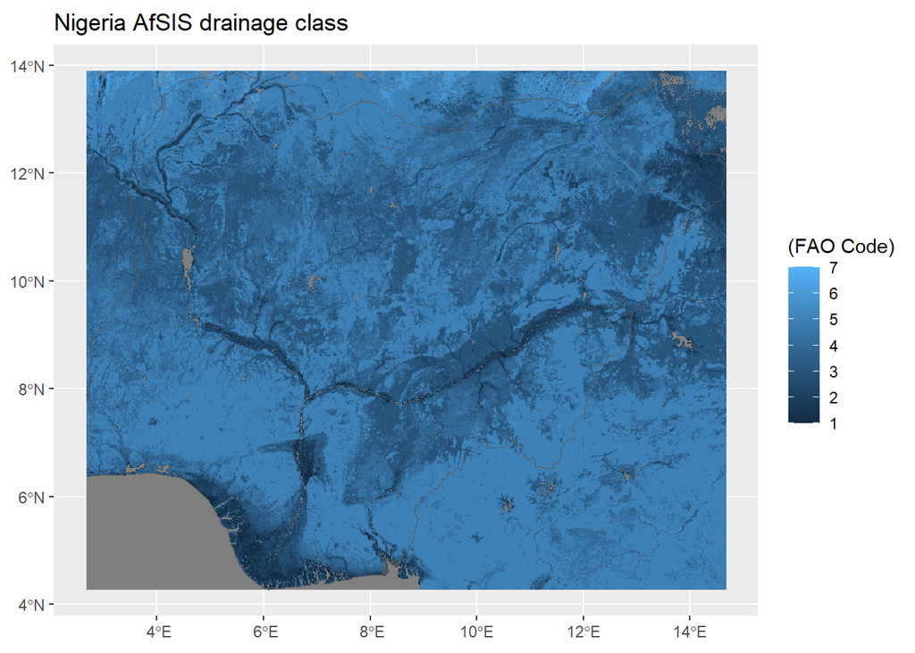

```r
# RUN ONCE TO GENERATE THE DATA - THEREAFTER THE SAVED DATA ARE LOADED FOR DISPLAY

# rast_af_drain <- rast("D:/DatosProyecto/SpatialData/Africa/biofisico/Soils/AfSIS/af_DRAINFAO_T__M_250m.tif")
#
# rast_af_drain
#
# rast_af_drain_ng <- crop(project(rast_af_drain, wkt_geo), vect_ng_geo)
#
# rast_af_drain_ng
#
# rm(rast_af_drain)
#
# gc()

# RUN ONCE TO SAVE THE DATA - THEREAFTER THE SAVED DATA ARE LOADED FOR DISPLAY

# writeRaster(rast_af_drain_ng, "E:/repos/IRM_shiny/data/spatial_data/af_DRAINFAO_T__M_250m_nigeria.tif", overwrite=TRUE)

rast_af_drain_ng <- rast("E:/repos/IRM_shiny/data/spatial_data/af_DRAINFAO_T__M_250m_nigeria.tif")


ggplot()+
  geom_spatraster(data = rast_af_drain_ng) +
  geom_spatvector(data = vect_ng_geo, fill = NA) +
  labs(
    title = "Nigeria AfSIS drainage class",
    fill = "(FAO Code)") +
  theme(
    plot.title = element_markdown(),
    legend.title = element_markdown(),
    axis.title = element_blank()
  )
```

Use ISRIC soilgrids for consistent coverage or country level soil data?

## Soil physical

### Texture

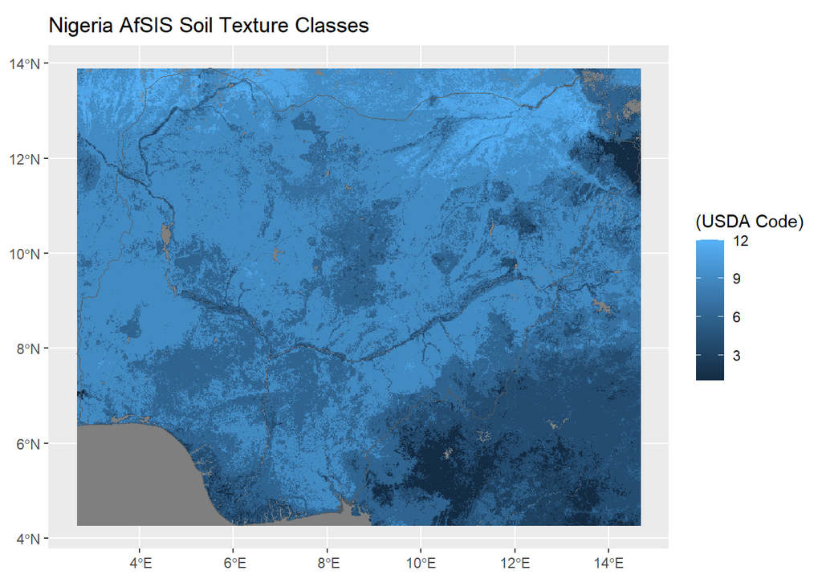

```r
# RUN ONCE TO GENERATE THE DATA - THEREAFTER THE SAVED DATA ARE LOADED FOR DISPLAY

# rast_af_text <- rast("E:/repos_external/RDC_Aptitud/spatial_data/input/af_TEXMHT_T__M_sd_all_250m_geo.tif")
#
# rast_af_text
#
# rast_af_text_ng <- crop(rast_af_text, vect_ng_geo)
#
# rast_af_text_ng
#
# rm(rast_af_text)
#
# gc()

# RUN ONCE TO SAVE THE DATA - THEREAFTER THE SAVED DATA ARE LOADED FOR DISPLAY

# writeRaster(rast_af_text_ng, "E:/repos/IRM_shiny/data/spatial_data/af_TEXMHT_T__M_sd_all_250m_nigeria.tif", overwrite=TRUE)

rast_af_text_ng <- rast("E:/repos/IRM_shiny/data/spatial_data/af_TEXMHT_T__M_sd_all_250m_nigeria.tif")


ggplot()+
  geom_spatraster(data = rast_af_text_ng$af_TEXMHT_T__M_sd_all_250m_geo_1) +
  geom_spatvector(data = vect_ng_geo, fill = NA) +
  labs(
    title = "Nigeria AfSIS Soil Texture Classes",
    fill = "(USDA Code)") +
  theme(
    plot.title = element_markdown(),
    legend.title = element_markdown(),
    axis.title = element_blank()
  )
```

### Soil depth

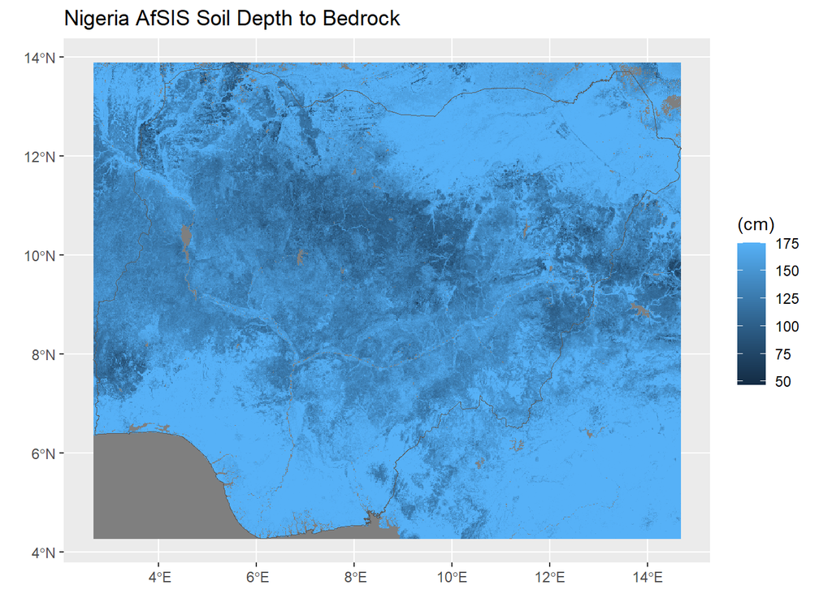

```r
# RUN ONCE TO GENERATE THE DATA - THEREAFTER THE SAVED DATA ARE LOADED FOR DISPLAY

# rast_af_depth <- rast("D:/DatosProyecto/SpatialData/Africa/biofisico/Soils/AfSIS/af_BDRICM_T__M_250m.tif")
#
# rast_af_depth
#
# rast_af_depth_ng <- crop(project(rast_af_depth, wkt_geo), vect_ng_geo)
#
# rast_af_depth_ng
#
# rm(rast_af_depth)
#
# gc()

# RUN ONCE TO SAVE THE DATA - THEREAFTER THE SAVED DATA ARE LOADED FOR DISPLAY

# writeRaster(rast_af_depth_ng, "E:/repos/IRM_shiny/data/spatial_data/af_BDRICM_T__M_250m_nigeria.tif", overwrite=TRUE)

rast_af_depth_ng <- rast("E:/repos/IRM_shiny/data/spatial_data/af_BDRICM_T__M_250m_nigeria.tif")


ggplot()+
  geom_spatraster(data = rast_af_depth_ng) +
  geom_spatvector(data = vect_ng_geo, fill = NA) +
  labs(
    title = "Nigeria AfSIS Soil Depth to Bedrock",
    fill = "(cm)") +
  theme(
    plot.title = element_markdown(),
    legend.title = element_markdown(),
    axis.title = element_blank()
  )
```

### Coarse fragments

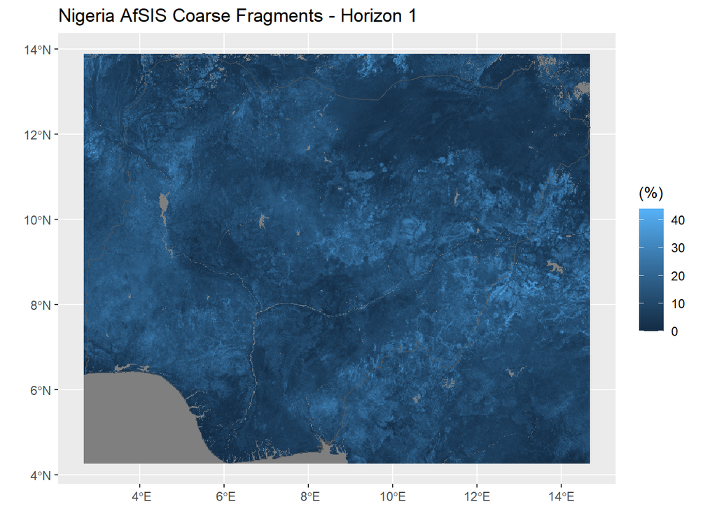

```r
# RUN ONCE TO GENERATE THE DATA - THEREAFTER THE SAVED DATA ARE LOADED FOR DISPLAY

# rast_af_cfrag_1 <- rast("D:/DatosProyecto/SpatialData/Africa/biofisico/Soils/AfSIS/af_CRFVOL_T__M_sd1_250m.tif") #|> project(wkt_geo)  |> crop(vect_ng_geo)
# rast_af_cfrag_2 <- rast("D:/DatosProyecto/SpatialData/Africa/biofisico/Soils/AfSIS/af_CRFVOL_T__M_sd2_250m.tif")
# rast_af_cfrag_3 <- rast("D:/DatosProyecto/SpatialData/Africa/biofisico/Soils/AfSIS/af_CRFVOL_T__M_sd3_250m.tif")
# rast_af_cfrag_4 <- rast("D:/DatosProyecto/SpatialData/Africa/biofisico/Soils/AfSIS/af_CRFVOL_T__M_sd4_250m.tif")
# rast_af_cfrag_5 <- rast("D:/DatosProyecto/SpatialData/Africa/biofisico/Soils/AfSIS/af_CRFVOL_T__M_sd5_250m.tif")
# rast_af_cfrag_6 <- rast("D:/DatosProyecto/SpatialData/Africa/biofisico/Soils/AfSIS/af_CRFVOL_T__M_sd6_250m.tif")
#
# rast_af_cfrag <- c(rast_af_cfrag_1, rast_af_cfrag_2, rast_af_cfrag_3, rast_af_cfrag_4, rast_af_cfrag_5, rast_af_cfrag_6)
#
# rast_af_cfrag
#
# rast_af_cfrag_ng <- crop(project(rast_af_cfrag, wkt_geo), vect_ng_geo)
#
# rast_af_cfrag_ng
#
# rm(rast_af_cfrag)
#
# gc()

# RUN ONCE TO SAVE THE DATA - THEREAFTER THE SAVED DATA ARE LOADED FOR DISPLAY

# writeRaster(rast_af_cfrag_ng, "E:/repos/IRM_shiny/data/spatial_data/af_CRFVOL_T__M_250m_nigeria.tif", overwrite=TRUE)

rast_af_cfrag_ng <- rast("E:/repos/IRM_shiny/data/spatial_data/af_CRFVOL_T__M_250m_nigeria.tif")


ggplot()+
  geom_spatraster(data = rast_af_cfrag_ng$af_CRFVOL_T__M_sd1_250m) +
  geom_spatvector(data = vect_ng_geo, fill = NA) +
  labs(
    title = "Nigeria AfSIS Coarse Fragments - Horizon 1",
    fill = "(%)") +
  theme(
    plot.title = element_markdown(),
    legend.title = element_markdown(),
    axis.title = element_blank()
  )
```

## Soil fertility

### Soil pH

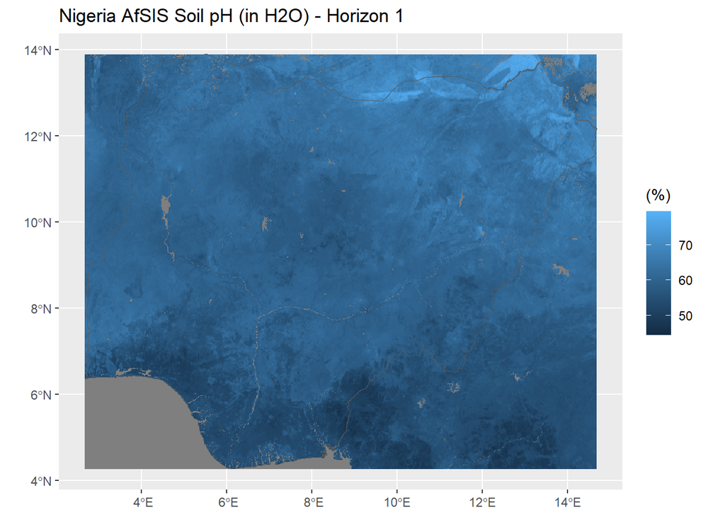

```r
# RUN ONCE TO GENERATE THE DATA - THEREAFTER THE SAVED DATA ARE LOADED FOR DISPLAY

# rast_af_ph_1 <- rast("D:/DatosProyecto/SpatialData/Africa/biofisico/Soils/AfSIS/af_PHIHOX_T__M_sd1_250m.tif")
# rast_af_ph_2 <- rast("D:/DatosProyecto/SpatialData/Africa/biofisico/Soils/AfSIS/af_PHIHOX_T__M_sd2_250m.tif")
# rast_af_ph_3 <- rast("D:/DatosProyecto/SpatialData/Africa/biofisico/Soils/AfSIS/af_PHIHOX_T__M_sd3_250m.tif")
# rast_af_ph_4 <- rast("D:/DatosProyecto/SpatialData/Africa/biofisico/Soils/AfSIS/af_PHIHOX_T__M_sd4_250m.tif")
# rast_af_ph_5 <- rast("D:/DatosProyecto/SpatialData/Africa/biofisico/Soils/AfSIS/af_PHIHOX_T__M_sd5_250m.tif")
# rast_af_ph_6 <- rast("D:/DatosProyecto/SpatialData/Africa/biofisico/Soils/AfSIS/af_PHIHOX_T__M_sd6_250m.tif")
#
# rast_af_ph <- c(rast_af_ph_1, rast_af_ph_2, rast_af_ph_3, rast_af_ph_4, rast_af_ph_5, rast_af_ph_6)
#
# rast_af_ph
#
# rast_af_ph_ng <- crop(project(rast_af_ph, wkt_geo), vect_ng_geo)
#
# rast_af_ph_ng
#
# rm(rast_af_ph)
#
# gc()

# RUN ONCE TO SAVE THE DATA - THEREAFTER THE SAVED DATA ARE LOADED FOR DISPLAY

# writeRaster(rast_af_ph_ng, "E:/repos/IRM_shiny/data/spatial_data/af_PHIHOX_T__M_250m_nigeria.tif", overwrite=TRUE)


rast_af_ph_ng <- rast("E:/repos/IRM_shiny/data/spatial_data/af_PHIHOX_T__M_250m_nigeria.tif")

ggplot()+
  geom_spatraster(data = rast_af_ph_ng$af_PHIHOX_T__M_sd1_250m) +
  geom_spatvector(data = vect_ng_geo, fill = NA) +
  labs(
    title = "Nigeria AfSIS Soil pH (in H2O) - Horizon 1",
    fill = "(%)") +
  theme(
    plot.title = element_markdown(),
    legend.title = element_markdown(),
    axis.title = element_blank()
  )
```

### SOC

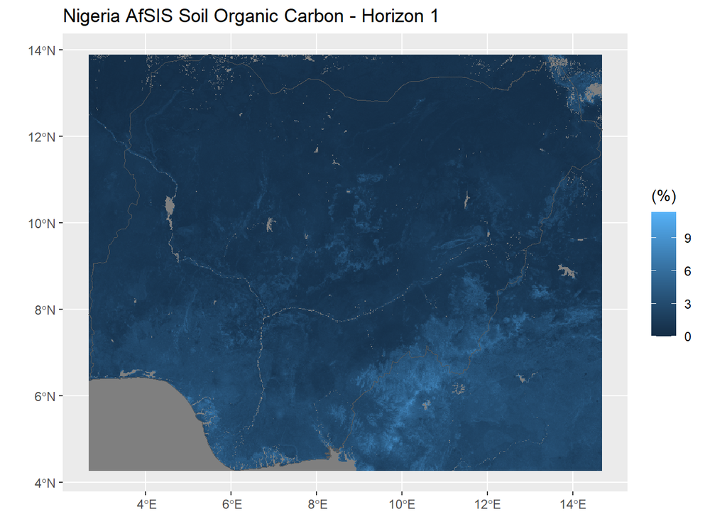

```r
# RUN ONCE TO GENERATE THE DATA - THEREAFTER THE SAVED DATA ARE LOADED FOR DISPLAY

# rast_af_soc <- rast("D:/DatosProyecto/SpatialData/Africa/biofisico/Soils/AfSIS/af_ORCDRC_T__M_sd1_250m.tif")
#
# rast_af_soc
#
# rast_af_soc_ng <- crop(project(rast_af_soc, wkt_geo), vect_ng_geo)
#
# # convert from permille to percent
# rast_af_soc_ng <- (rast_af_soc_ng / 10)
#
# rm(rast_af_soc)
#
# gc()

# RUN ONCE TO SAVE THE DATA - THEREAFTER THE SAVED DATA ARE LOADED FOR DISPLAY

# writeRaster(rast_af_soc_ng, "E:/repos/IRM_shiny/data/spatial_data/af_ORCPC_T__M_sd1_250m_nigeria.tif", overwrite=TRUE)

rast_af_soc_ng <- rast("E:/repos/IRM_shiny/data/spatial_data/af_ORCPC_T__M_sd1_250m_nigeria.tif")


ggplot()+
  geom_spatraster(data = rast_af_soc_ng) +
  geom_spatvector(data = vect_ng_geo, fill = NA) +
  labs(
    title = "Nigeria AfSIS Soil Organic Carbon - Horizon 1",
    fill = "(%)") +
  theme(
    plot.title = element_markdown(),
    legend.title = element_markdown(),
    axis.title = element_blank()
  )
```